# Practical Machine Learning Final Assignment

Jerry Finn

January 2018

```r
library(caret)
library(kernlab)
library(dplyr)
library(kableExtra)
library(rattle)
```

## Intro

The intention of this investigation is to compare classification techniques and determine which has greater accuracy (smaller out of sample error) without having excesive computations.

## Data Processing

### Importing the data

The data set is rather sparce with regards to some features. Also we need to specify that blanks are NA.

```r
training <- read.csv("pml-training.csv", na.strings = c(NA, ""))
testing <- read.csv("pml-testing.csv", na.strings = c(NA, ""))
```

To get rid of sparce features, we are going to remove columns with NA values. Many of these are aggregations of other values and don’t convey information. Also the first columns are just labels and not predictive, so we remove them.

```r
removecol <- colnames(training)[colSums(is.na(training)) > 0]
reducetraining <- training[ , -which(names(training) %in% c(removecol))]
reducetraining <- reducetraining[, -c(1,2,3,4,5,6,7)]
```

Here we’ll split the data 70 to 30%, which according to our lectures are quite common.

```r
keepcolumns = c(names(reducetraining))
newtesting = testing[, keepcolumns[!keepcolumns %in% "classe"]]

splitdf <- createDataPartition(reducetraining$classe, p=0.7, list=FALSE)
traindf <- reducetraining[splitdf,]
testdf <- reducetraining[-splitdf,]
```

## Running the models and comparison

### Model Selection

Tree algorithms are very popular for classification problems. We’ll try 3. 1st, a single decision tree, the rpart method.

2nd, we’ll use the Bagged CART method, which will resample cases and recalculate predictions, and then average on majority vote. Since this is a non-linear function it should perform well.

Finally we will use Random Forest, which is gained a reputation for accuracy (usually one of the two top performing algorithms) although it could be computationally expensive.

```r
tc <- trainControl(method='cv', number = 3)

modCart <- train(classe ~ ., data=traindf, trControl=tc,  method='rpart')

modTb = train(classe ~ ., data = traindf, method="treebag")

modRf <- train(classe ~ ., data=traindf, trControl=tc,   method='rf', ntree=100)
```

### Confusion Matrix and Accuracy

Now we’ll use our test data for measuring accuracy.

```r
pCart <- predict(modCart, newdata=testdf)
confusCart <- confusionMatrix(pCart, testdf$classe)
pTb <- predict(modTb, newdata=testdf)
confusTb <- confusionMatrix(pTb, testdf$classe)
pRf <- predict(modRf, newdata=testdf)
confusRf<- confusionMatrix(pRf, testdf$classe)
```

### Model Comparison

#### CART Model

```r
t1 <- confusCart$table
knitr::kable(t1) %>% kable_styling(position = "center")
```

|  | A | B | C | D | E |
| --- | --- | --- | --- | --- | --- |
| A | 1524 | 479 | 481 | 441 | 149 |
| B | 20 | 380 | 34 | 181 | 150 |
| C | 126 | 280 | 511 | 342 | 303 |
| D | 0 | 0 | 0 | 0 | 0 |
| E | 4 | 0 | 0 | 0 | 480 |

Accuracy: 0.4919286

The model ran quickly and when I saved the model to a RDS file, it was 21MB. We can see from the output that the predictive power of this model is not good. Let’s see why.

#### Decision Tree Graph

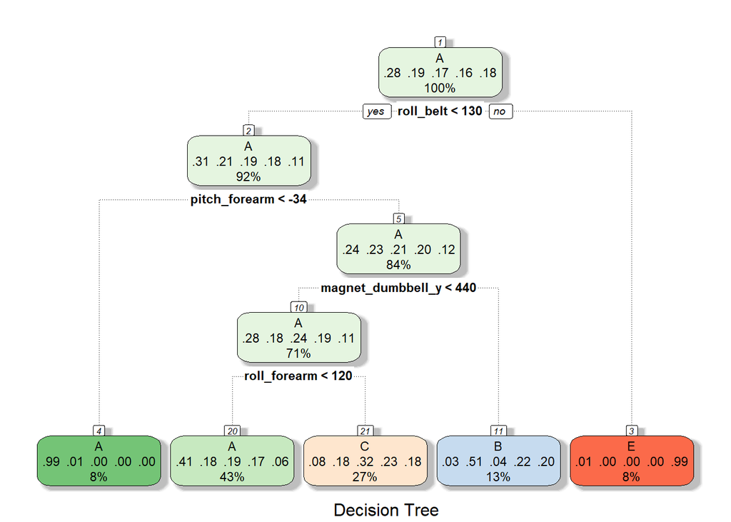

```r
fancyRpartPlot(modCart$finalModel, caption = "Decision Tree")
```

We can see that the tree is skewed towards A. If we look at a table of the classe variable we can see that A is more frequent in the data.

```r
table(training$classe)
```

```
##
##    A    B    C    D    E
## 5580 3797 3422 3216 3607
```

So our out of sample error (mistakes on the test data set) could be determined if the test data is skewed differently from the training.

Therefore we need a more sophisticated model.

#### Tree Bagging

```r
t2 <- confusTb$table
knitr::kable(t2)
```

|  | A | B | C | D | E |
| --- | --- | --- | --- | --- | --- |
| A | 1672 | 1 | 0 | 0 | 0 |
| B | 1 | 1136 | 4 | 2 | 0 |
| C | 1 | 2 | 1020 | 2 | 1 |
| D | 0 | 0 | 2 | 960 | 1 |
| E | 0 | 0 | 0 | 0 | 1080 |

Accuracy: 0.9971113

The tree bag method gave respectable accuracy, (and therefore a lower out of sample error) but it took a long time to run and when saved to a RDS file, the model was over 300MB in size. It would be nice to have a accurate model that is less expensive.

#### Random Forest

```r
t3 <- confusRf$table
knitr::kable(t3)
```

|  | A | B | C | D | E |
| --- | --- | --- | --- | --- | --- |
| A | 1674 | 1 | 0 | 0 | 0 |
| B | 0 | 1136 | 3 | 0 | 0 |
| C | 0 | 2 | 1022 | 1 | 1 |
| D | 0 | 0 | 1 | 963 | 1 |
| E | 0 | 0 | 0 | 0 | 1080 |

Accuracy: 0.9983008

Now we have a high level of accuracy, the model ran quickly and only takes up 2MB on disk.

## Conclusion

Therefore, lets use random forest for the final prediction for the quiz.

```r
quiz= predict(modRf, newdata=newtesting)
quiz
```

```
##  [1] B A B A A E D B A A B C B A E E A B B B
## Levels: A B C D E
```

I submitted this and got them all right.

The CART model, while not computationally expensive, was not accurate. When I ran the models, the accuracy of the Tree Bagging mode and the Random Forest were very close but the Random Forest was always very slightly better than Tree Bagging. However, the Random Forest model ran faster and when saved to disk in a RDS file it was about 100 times less disk space. Therefore, Random Forest gave us the best results at the lowest cost.